# Bat Flight Simulation

Quantitative Methods in Ecology and Evolution

Justin Benjamin & Renata Soljmosi

April 4th, 2024

## Introduction

- Big brown bats (*Eptesicus fuscus*)
- Captive colony at McMaster University
- Previously we found they weren’t willing/able to fly in captivity
- Planning a new study to examine whether exercise via treadmill can help captive bats become more willing and able to fly
- Don’t have data yet as this is an upcoming study
- Our project aims to simulate and analyze data

## Study design

- Repeated measures study with 30 bats measured every 3 days over 60 days
- **Predictor variables**
  - Day
  - Treatment (exercise or no exercise)
- **Response variables**
  - Mass (grams)
  - Flight time (s): flight ability
  - Number of “shakes” needed for bat to take off: flight willingness

## Hypothesis and predictions

- **Research Question:** Does non-flight exercise improve bat flight ability/willingness in a meaningful way?
- **Predictions:**
  - Exercised bats will have longer flight times than non-exercised bats
  - Exercised bats will need less shakes to fly than non-exercised bats

## Simulation process

- Choose parameters
- Simulate data using these parameters and ensure they seem reasonable
- Wrap in a function to repeat many times

## Simulation example (flight time)

### Set up to create a simulation function

```r
set.seed(202)

n_per_group=15; days=seq(0, 60, by=3)
n_groups <- 2
n_bats <- n_per_group*n_groups
```

```r
form0 <- ~ 1 + day + treatment:day + (day | batID)
```

**1**: intercept; **day**: the effect of day on flight time;

**treatment:day**: interaction (the effect of day on flight time varies depending on treatment level)

**(day | batID)**: random effects (accounts for correlation among observations within the same levels of “batID”, allowing for individual variation in the intercept and slope of the variable “day”)

```r
β0=2; β_day=(0.5/60); β_daytreat=(2/60)
corr_trans <- function(rho) rho/(sqrt(1+rho^2))
corr=corr_trans(0.75)
sdint=0.5; sdslope=(0.5/60); sdres=0.1
```

**β0**: intercept; **β_day**: change in flight time for control; **β_daytreat**: *additional* change in flight time in treatment group

**corr**: correlation between intercepts and slopes. **rho** (0.75) transformed with corr_trans

**sdint**: standard deviation of intercept; **sdslope**: standard deviation of slope; **sdres**: standard deviation of residual variance

```r
sim <- function(n_per_group, days, β0, β_day, β_daytreat
                , sdint, sdslope, corr, sdres, ...
){
  batID <- as.factor(1:n_bats)
  treatment <- as.factor(rep(c("control", "exercise"), each=n_per_group))
  tdat <- data.frame(batID, treatment)
  dat1 <- expand.grid(batID=batID, day=days)
  flight_data <- full_join(dat1, tdat, by="batID")
  flightTime <- simulate_new(form0,
                            nsim = 1,
                            family = "gaussian",
                            newdata = flight_data,
                            newparams = list(
                              beta = c(β0, β_day, β_daytreat)
                              , theta = c(log(sdint), log(sdslope), corr)
                              , betad = log(sdres)
                            )
  )

  flight_data$flightTime <- flightTime[[1]]
  return(flight_data)
}
```

This creates a data simulation function

### Simulate once and plot to ensure it looks reasonable

```r
s1 <- sim(n_per_group=n_per_group, days=days
          , β0=β0, β_day=β_day, β_daytreat=β_daytreat
          , sdint=sdint, sdslope=sdslope, corr=corr, sdres=sdres)
```

This applies our set parameters to simulate a data set

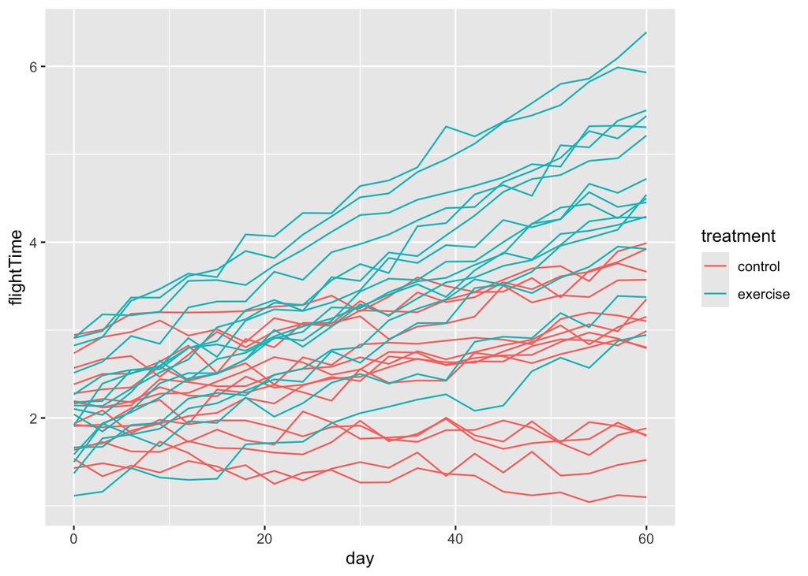

### Wrap in a function to repeat many times

Our model:

```r
form1 <- flightTime ~ 1 + day + treatment:day + (day | batID)
```

```r
fit <- function(flight_data){
  return(glmmTMB(form1
                 , data=flight_data
                 , family = "gaussian"
  ))
}
```

This creates a model fitting function

```r
simCIs <- function(simfun, fitfun, ...){
  dat <- simfun(...)
  fit <- fitfun(dat)
  tt <- (tidy(fit, effects = "fixed", conf.int = TRUE)
         %>% select(term, est = estimate, lwr = conf.low, upr = conf.high)
         %>% mutate(across(where(is.character), factor))
  )
  return(tt)
}
```

This creates a function that simulates data, models it, and extracts the coefficients and their confidence intervals

```r
nReps <- 1000
flightTime <- map_dfr(1:nReps, simCIs, .id="sim_flight"
                 , .progress = interactive()
                 , simfun=sim, fitfun=fit
                 , n_per_group = n_per_group, days=days
                 , β0=β0, β_day=β_day, β_daytreat=β_daytreat
                 , sdint=sdint, sdslope=sdslope, corr=corr, sdres=sdres
  )
```

This applies the simCI function from the previous slide iteratively to simulate data, model it, and extract the coefficients and confidence intervals 1000 times

### Examine the data

```r
summary(flightTime)
```

```
##   sim_flight                           term           est
##  Length:3000        (Intercept)          :1000   Min.   :0.002981
##  Class :character   day                  :1000   1st Qu.:0.009760
##  Mode  :character   day:treatmentexercise:1000   Median :0.033382
##                                                  Mean   :0.681477
##                                                  3rd Qu.:1.943585
##                                                  Max.   :2.290864
##       lwr                 upr
##  Min.   :-0.001184   Min.   :0.006025
##  1st Qu.: 0.005897   1st Qu.:0.013615
##  Median : 0.028274   Median :0.038395
##  Mean   : 0.620257   Mean   :0.742697
##  3rd Qu.: 1.760976   3rd Qu.:2.115766
##  Max.   : 2.143672   Max.   :2.484574
```

```r
treatmentTrue_flightTime <- β_daytreat #(2/60)
```

This is the *simulated* (true) value of the parameter we’re testing, (i.e. the average *additional* increase in flight time per day [relative to control] in treatment group)

```r
dt_flight <- (flightTime
              %>% filter(term=="day:treatmentexercise")
              %>% drop_na()
)
```

This filters out the rows we are interested in: those where the value in the column term is day:treatmentexercise

```r
dt_flight %>% summarize(
  toohigh=mean(lwr>treatmentTrue_flightTime)
  , toolow=mean(upr<treatmentTrue_flightTime)
  , ci_width=mean(upr-lwr)
  , power = mean(lwr>0)
)
```

```
## # A tibble: 1 × 4
##   toohigh toolow ci_width power
##     <dbl>  <dbl>    <dbl> <dbl>
## 1   0.039   0.04   0.0101     1
```

This extracts the relevant information regarding the confidence intervals

## Visualize the data

### Caterpillar plot

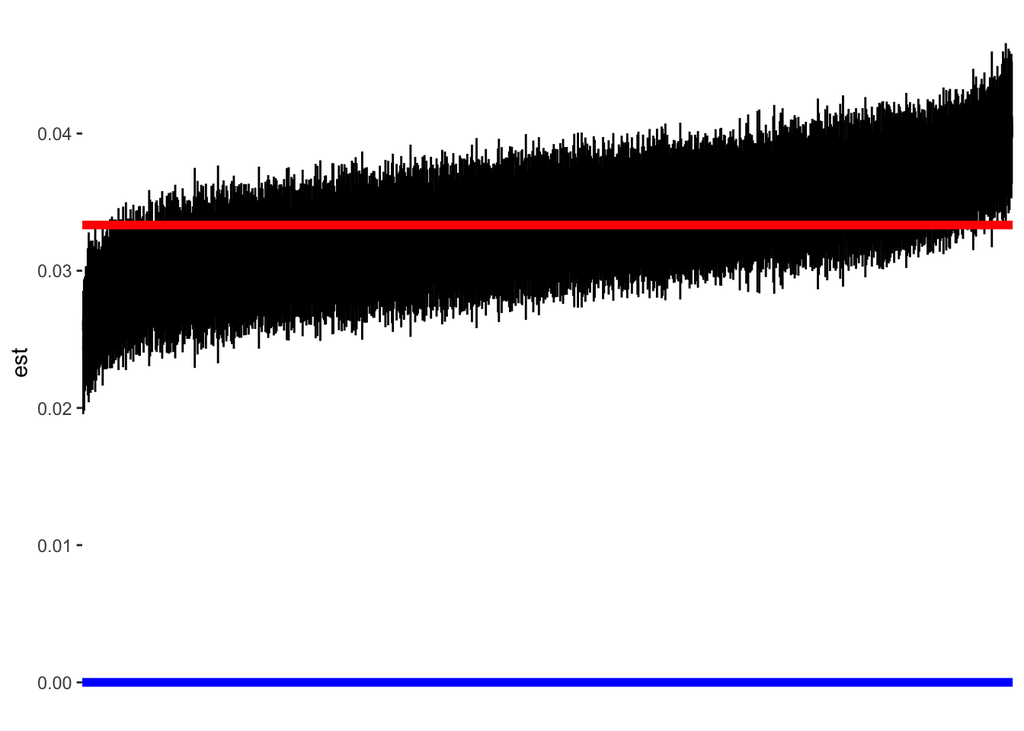

```r
print(gg1)
```

##Simulated mass data

Very similar procedure because mass is also a continuous response variable.

Our model:

```r
form1_m <- mass ~ 1 + day + treatment:day + (day | batID)
```

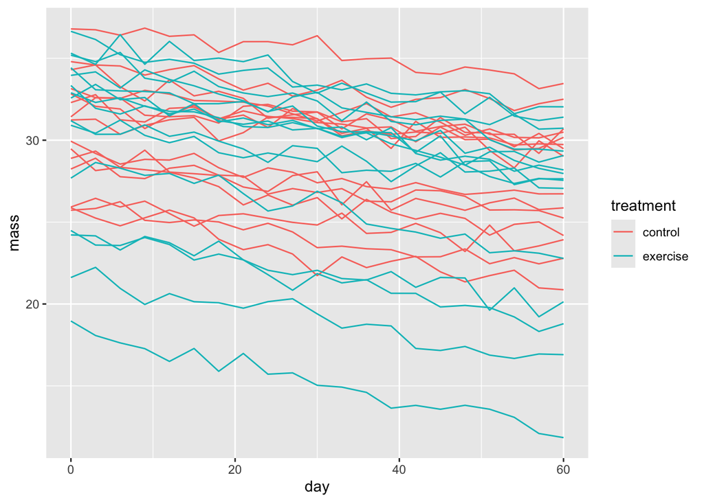

```r
plot_sim2(s2)
```

```r
summary(mass)
```

```
##      sim                               term           est
##  Length:3000        (Intercept)          :1000   Min.   :-0.06725
##  Class :character   day                  :1000   1st Qu.:-0.04687
##  Mode  :character   day:treatmentexercise:1000   Median :-0.02559
##                                                  Mean   : 9.97220
##                                                  3rd Qu.:29.43966
##                                                  Max.   :33.14796
##       lwr                upr
##  Min.   :-0.07462   Min.   :-0.05988
##  1st Qu.:-0.05469   1st Qu.:-0.03878
##  Median :-0.03598   Median :-0.01518
##  Mean   : 9.38149   Mean   :10.56292
##  3rd Qu.:27.62198   3rd Qu.:31.13238
##  Max.   :31.28185   Max.   :35.05596
```

```r
dt_mass %>% summarize(
                toohigh=mean(lwr>treatmentTrue_mass)
              , toolow=mean(upr<treatmentTrue_mass)
              , ci_width=mean(upr-lwr)
              , power = mean(upr<0)
            )
```

```
## # A tibble: 1 × 4
##   toohigh toolow ci_width power
##     <dbl>  <dbl>    <dbl> <dbl>
## 1   0.039  0.031   0.0209 0.989
```

### Caterpillar plot

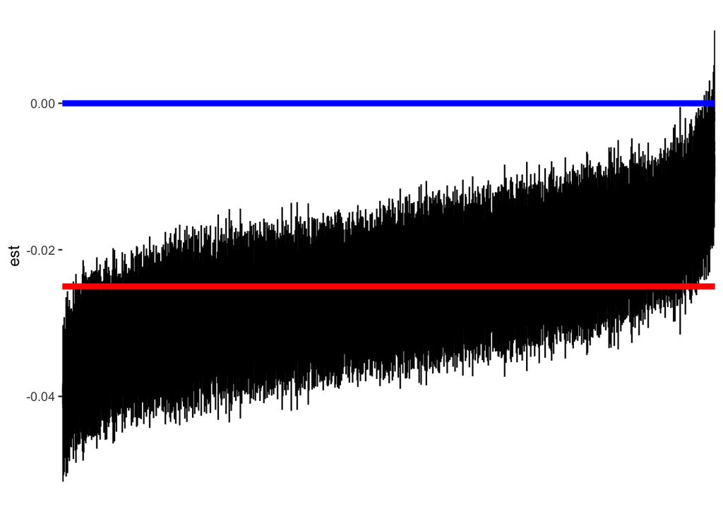

```r
print(gg2)
```

## Next steps

- Simulation with shakes as count data (Negative binomial or Poisson models)
- Mass as a predictor variable?
- Analyses